# Teen Smartphone Usage and Addiction Impact Dataset

Aleksandra Dobosz, Aleksandra Engel, Adam Gonet, Kamil Laskowski

2026-05-04

# Teen Smartphone Usage and Addiction Impact Dataset

## About the Project

This is an R version of project conducted for Machine Learning project in Python. All codes are fully converted into R version, comments and descriptions for preparation and modelling parts are taken from the python version of this project.

This version is additionally extended by adding additional data and prediction on this new set of data. This is the last part of this report. The goal is to check and experiment how ML modelling is different in R and if the model can achieve satisfactory results on randomly generated data.

## About the Dataset

This dataset, sourced from Kaggle, focuses on understanding **smartphone usage patterns among teenagers** and the impact of excessive phone use on their **academic performance, mental health, and daily lifestyle**. With the rapid increase in smartphone dependency among adolescents, it has become important to study how usage habits influence well-being and performance.

The dataset captures multiple aspects of teenage behavior, including **addiction levels, time distribution across activities, sleep patterns, social interactions, and mental health indicators**. From our perspective, we aim to build regression models to examine which factors have the greatest impact on smartphone addiction levels.

## Column Descriptions

Demographic Information

- **ID**: Unique identifier for each student
- **Name**: Name of the student
- **Age**: Age of the teenager
- **Gender**: Gender of the student
- **Location**: Geographic location
- **School_Grade**: Current academic or level

Smartphone Usage & Time Distribution

- **Daily_Usage_Hours**: Average smartphone usage per day (hours)
- **Weekend_Usage_Hours**: Average smartphone usage on weekends
- **Screen_Time_Before_Bed**: Screen time before going to sleep
- **Phone_Checks_Per_Day**: Number of times the phone is checked daily
- **Apps_Used_Daily**: Number of apps used per day

Activity-Based Usage

- **Time_on_Social_Media**: Hours spent on social media platforms
- **Time_on_Gaming**: Hours spent on mobile gaming
- **Time_on_Education**: Hours spent on educational activities
- **Phone_Usage_Purpose**: Primary purpose of smartphone usage

Health & Lifestyle Indicators

- **Sleep_Hours**: Average hours of sleep per day
- **Exercise_Hours**: Time spent on physical exercise
- **Anxiety_Level**: Indicator of anxiety level
- **Depression_Level**: Indicator of depression level
- **Self_Esteem**: Self-esteem score

Social & Family Factors

- **Social_Interactions**: Level of in-person social interaction
- **Family_Communication**: Quality or frequency of communication with family
- **Parental_Control**: Level of parental monitoring or restrictions

Outcome Variables

- **Academic_Performance**: Indicator of academic performance
- **Addiction_Level**: Level of smartphone addiction (target variable)

## Problem Description

Smartphone use has become an essential part of teenagers’ daily lives, but excessive usage may lead to addiction and negatively affect mental health, sleep patterns, social interactions, and academic performance. Smartphone addiction among adolescents is an increasingly important social and psychological issue. The goal of this project is to use regression analysis to identify which behavioral, lifestyle, and psychological factors most strongly influence the level of smartphone addiction. Understanding these relationships can support early intervention and promote healthier smartphone usage habits among teenagers.

# Importing neccessary libraries

```r
# path to google file with data
file_id <- "1mJ-iLbHWiaPLHltrnIwjfNcbtW_4u8fd"
url <- paste0("https://drive.google.com/uc?export=download&id=", file_id)
df <- read.csv(url)
```

# Section 1: Data Loading and Initial Exploration

In this section, we load the dataset and perform initial exploratory analysis to understand the data structure, identify potential issues, and assess data quality.

```r
# print dataset dimensions (rows and columns)
cat("Dataset shape:", dim(df), "\n")
```

```
## Dataset shape: 3000 25
```

```r
# display first few rows of the dataset
head(df)
```

```
##   ID              Name Age Gender           Location School_Grade
## 1  1   Shannon Francis  13 Female         Hansonfort          9th
## 2  2   Scott Rodriguez  17 Female       Theodorefort          7th
## 3  3       Adrian Knox  13  Other        Lindseystad         11th
## 4  4 Brittany Hamilton  18 Female       West Anthony         12th
## 5  5      Steven Smith  14  Other   Port Lindsaystad          9th
## 6  6        Mary Adams  13 Female East Angelachester         10th
##   Daily_Usage_Hours Sleep_Hours Academic_Performance Social_Interactions
## 1               4.0         6.1                   78                   5
## 2               5.5         6.5                   70                   5
## 3               5.8         5.5                   93                   8
## 4               3.1         3.9                   78                   8
## 5               2.5         6.7                   56                   4
## 6               3.9         6.3                   89                   3
##   Exercise_Hours Anxiety_Level Depression_Level Self_Esteem Parental_Control
```

[output cut: 27 more lines]

```r
# descriptive statistics of the dataset
summary(df)
```

```
##        ID             Name                Age           Gender
##  Min.   :   1.0   Length:3000        Min.   :13.00   Length:3000
##  1st Qu.: 750.8   Class :character   1st Qu.:14.00   Class :character
##  Median :1500.5   Mode  :character   Median :16.00   Mode  :character
##  Mean   :1500.5                      Mean   :15.97
##  3rd Qu.:2250.2                      3rd Qu.:18.00
##  Max.   :3000.0                      Max.   :19.00
##    Location         School_Grade       Daily_Usage_Hours  Sleep_Hours
##  Length:3000        Length:3000        Min.   : 0.000    Min.   : 3.00
##  Class :character   Class :character   1st Qu.: 3.700    1st Qu.: 5.50
##  Mode  :character   Mode  :character   Median : 5.000    Median : 6.50
##                                        Mean   : 5.021    Mean   : 6.49
##                                        3rd Qu.: 6.400    3rd Qu.: 7.50
##                                        Max.   :11.500    Max.   :10.00
##  Academic_Performance Social_Interactions Exercise_Hours  Anxiety_Level
##  Min.   : 50.00       Min.   : 0.000      Min.   :0.000   Min.   : 1.00
##  1st Qu.: 62.00       1st Qu.: 2.000      1st Qu.:0.500   1st Qu.: 3.00
##  Median : 75.00       Median : 5.000      Median :1.000   Median : 6.00
##  Mean   : 74.95       Mean   : 5.098      Mean   :1.041   Mean   : 5.59
##  3rd Qu.: 88.00       3rd Qu.: 8.000      3rd Qu.:1.500   3rd Qu.: 8.00
##  Max.   :100.00       Max.   :10.000      Max.   :4.000   Max.   :10.00
##  Depression_Level  Self_Esteem     Parental_Control Screen_Time_Before_Bed
##  Min.   : 1.00    Min.   : 1.000   Min.   :0.0000   Min.   :0.000
##  1st Qu.: 3.00    1st Qu.: 3.000   1st Qu.:0.0000   1st Qu.:0.700
##  Median : 5.00    Median : 6.000   Median :1.0000   Median :1.000
##  Mean   : 5.46    Mean   : 5.546   Mean   :0.5073   Mean   :1.007
##  3rd Qu.: 8.00    3rd Qu.: 8.000   3rd Qu.:1.0000   3rd Qu.:1.400
##  Max.   :10.00    Max.   :10.000   Max.   :1.0000   Max.   :2.600
##  Phone_Checks_Per_Day Apps_Used_Daily Time_on_Social_Media Time_on_Gaming
##  Min.   : 20.00       Min.   : 5.00   Min.   :0.000        Min.   :0.000
##  1st Qu.: 51.00       1st Qu.: 9.00   1st Qu.:1.800        1st Qu.:0.800
##  Median : 82.00       Median :13.00   Median :2.500        Median :1.500
##  Mean   : 83.09       Mean   :12.61   Mean   :2.499        Mean   :1.525
##  3rd Qu.:115.25       3rd Qu.:17.00   3rd Qu.:3.200        3rd Qu.:2.200
##  Max.   :150.00       Max.   :20.00   Max.   :5.000        Max.   :4.000
##  Time_on_Education Phone_Usage_Purpose Family_Communication Weekend_Usage_Hours
##  Min.   :0.000     Length:3000         Min.   : 1.00        Min.   : 0.000
##  1st Qu.:0.500     Class :character    1st Qu.: 3.00        1st Qu.: 4.700
##  Median :1.000     Mode  :character    Median : 5.00        Median : 6.000
##  Mean   :1.016                         Mean   : 5.46        Mean   : 6.015
##  3rd Qu.:1.500                         3rd Qu.: 8.00        3rd Qu.: 7.400
##  Max.   :3.000                         Max.   :10.00        Max.   :14.000
##  Addiction_Level
##  Min.   : 1.000
##  1st Qu.: 8.000
##  Median :10.000
##  Mean   : 8.882
##  3rd Qu.:10.000
##  Max.   :10.000
```

```r
# count duplicated rows in the dataset
sum(duplicated(df))
```

```
## [1] 0
```

```r
# count missing values in each column
colSums(is.na(df))
```

```
##                     ID                   Name                    Age
##                      0                      0                      0
##                 Gender               Location           School_Grade
##                      0                      0                      0
##      Daily_Usage_Hours            Sleep_Hours   Academic_Performance
##                      0                      0                      0
##    Social_Interactions         Exercise_Hours          Anxiety_Level
##                      0                      0                      0
##       Depression_Level            Self_Esteem       Parental_Control
##                      0                      0                      0
## Screen_Time_Before_Bed   Phone_Checks_Per_Day        Apps_Used_Daily
##                      0                      0                      0
##   Time_on_Social_Media         Time_on_Gaming      Time_on_Education
##                      0                      0                      0
##    Phone_Usage_Purpose   Family_Communication    Weekend_Usage_Hours
##                      0                      0                      0
##        Addiction_Level
##                      0
```

Now as we have don’t have missing values, we are going to remove unnecessary columns and test-train split.

# Section 2: Data Cleaning and Preprocessing

Now we’ll remove unnecessary columns and split the data into training and test sets. Then, we’ll apply one-hot encoding to categorical variables.

### Step 1: Remove non-informative columns

Columns like ‘Name’ and ‘ID’ don’t contribute to predictions since they are just identifiers. We’ll drop them to reduce noise.

```r
# remove selected columns using dplyr
df <- df %>% select(-Name, -ID)
```

### Step 2: Train-Test Split

We split the data into 80% training and 20% testing sets. Using random_state=123, which ensures reproducibility.

```r
set.seed(123)

index <- createDataPartition(df[[1]], p = 0.8, list = FALSE)

df_train <- df[index, ]
df_test  <- df[-index, ]

# display training set
head(df_train)
```

```
##   Age Gender           Location School_Grade Daily_Usage_Hours Sleep_Hours
## 2  17 Female       Theodorefort          7th               5.5         6.5
## 3  13  Other        Lindseystad         11th               5.8         5.5
## 4  18 Female       West Anthony         12th               3.1         3.9
## 6  13 Female East Angelachester         10th               3.9         6.3
## 7  16   Male      North Jeffrey         11th               6.3         6.7
## 8  13  Other       Jenniferport         10th               5.1         6.1
##   Academic_Performance Social_Interactions Exercise_Hours Anxiety_Level
## 2                   70                   5            0.0             3
## 3                   93                   8            0.8             2
## 4                   78                   8            1.6             9
## 6                   89                   3            0.7             7
## 7                   89                   3            0.9             6
## 8                   70                   2            2.2             5
##   Depression_Level Self_Esteem Parental_Control Screen_Time_Before_Bed
```

[output cut: 27 more lines]

```r
cat("SHAPE:", dim(df_train), "\n")
```

```
## SHAPE: 2401 23
```

```r
# display test set
head(df_test)
```

```
##    Age Gender          Location School_Grade Daily_Usage_Hours Sleep_Hours
## 1   13 Female        Hansonfort          9th               4.0         6.1
## 5   14  Other  Port Lindsaystad          9th               2.5         6.7
## 10  18  Other       Prestonview         11th               3.9         5.8
## 17  15 Female        Lake Chase          8th               5.4         7.8
## 26  16   Male       Port Bianca         11th               5.5         5.9
## 27  19   Male West Kimberlyfurt         11th               6.2         4.5
##    Academic_Performance Social_Interactions Exercise_Hours Anxiety_Level
## 1                    78                   5            0.1            10
## 5                    56                   4            1.1             1
## 10                   89                   8            1.1             9
## 17                   87                   4            2.3             6
## 26                   78                   5            1.2             1
## 27                   65                   3            1.3             5
##    Depression_Level Self_Esteem Parental_Control Screen_Time_Before_Bed
```

[output cut: 27 more lines]

```r
cat("SHAPE:", dim(df_test), "\n")
```

```
## SHAPE: 599 23
```

### Step 3: Analyze data types and cardinality

Let’s examine the data types and unique values for each column to identify categorical variables that need encoding.

```r
# structure of dataset
glimpse(df_train)
```

```
## Rows: 2,401
## Columns: 23
## $ Age                    <int> 17, 13, 18, 13, 16, 13, 13, 18, 14, 19, 17, 15,…
## $ Gender                 <chr> "Female", "Other", "Female", "Female", "Male", …
## $ Location               <chr> "Theodorefort", "Lindseystad", "West Anthony", …
## $ School_Grade           <chr> "7th", "11th", "12th", "10th", "11th", "10th", …
## $ Daily_Usage_Hours      <dbl> 5.5, 5.8, 3.1, 3.9, 6.3, 5.1, 3.0, 4.9, 1.6, 7.…
## $ Sleep_Hours            <dbl> 6.5, 5.5, 3.9, 6.3, 6.7, 6.1, 9.1, 7.0, 5.9, 5.…
## $ Academic_Performance   <int> 70, 93, 78, 89, 89, 70, 79, 74, 70, 70, 95, 79,…
## $ Social_Interactions    <int> 5, 8, 8, 3, 3, 2, 0, 5, 10, 4, 6, 3, 6, 5, 6, 4…
## $ Exercise_Hours         <dbl> 0.0, 0.8, 1.6, 0.7, 0.9, 2.2, 1.8, 0.6, 1.5, 0.…
## $ Anxiety_Level          <int> 3, 2, 9, 7, 6, 5, 1, 4, 10, 4, 2, 2, 8, 1, 5, 2…
## $ Depression_Level       <int> 7, 3, 10, 1, 7, 6, 7, 3, 8, 9, 8, 8, 10, 4, 2, …
## $ Self_Esteem            <int> 3, 10, 3, 3, 9, 8, 6, 2, 8, 3, 2, 9, 4, 2, 4, 8…
## $ Parental_Control       <int> 0, 0, 0, 0, 0, 0, 0, 0, 0, 0, 1, 1, 1, 1, 1, 0,…
## $ Screen_Time_Before_Bed <dbl> 0.9, 0.5, 1.4, 1.1, 0.8, 1.0, 0.9, 0.6, 0.9, 1.…
## $ Phone_Checks_Per_Day   <int> 96, 137, 128, 135, 129, 34, 70, 84, 147, 59, 76…
## $ Apps_Used_Daily        <int> 9, 8, 7, 8, 9, 7, 13, 20, 18, 19, 8, 14, 17, 16…
## $ Time_on_Social_Media   <dbl> 1.1, 0.3, 3.1, 3.8, 1.8, 2.3, 2.7, 3.1, 1.9, 4.…
## $ Time_on_Gaming         <dbl> 4.0, 1.5, 1.6, 0.0, 2.7, 1.6, 2.2, 0.6, 2.7, 0.…
## $ Time_on_Education      <dbl> 1.8, 0.4, 0.8, 1.4, 1.0, 0.5, 1.3, 0.8, 1.0, 0.…
## $ Phone_Usage_Purpose    <chr> "Browsing", "Education", "Social Media", "Socia…
## $ Family_Communication   <int> 2, 6, 8, 7, 7, 9, 10, 6, 7, 8, 5, 5, 4, 7, 5, 7…
## $ Weekend_Usage_Hours    <dbl> 5.3, 5.7, 3.0, 6.0, 7.8, 8.0, 9.1, 3.5, 3.2, 9.…
## $ Addiction_Level        <dbl> 10.0, 9.2, 9.8, 8.8, 10.0, 8.0, 7.3, 10.0, 9.8,…
```

```r
# unique values
unique(df_train$School_Grade)
```

```
## [1] "7th"  "11th" "12th" "10th" "8th"  "9th"
```

```r
unique(df_train$Gender)
```

```
## [1] "Female" "Other"  "Male"
```

```r
# count unique values
n_distinct(df_train$Location)
```

```
## [1] 2231
```

```r
# remove column
df_train <- df_train %>% select(-Location)

# unique values
unique(df_train$Phone_Usage_Purpose)
```

```
## [1] "Browsing"     "Education"    "Social Media" "Other"        "Gaming"
```

Based on the above analysis, we need to apply one-hot encoding to School_Grade, Gender and Phone_Usage_Purpose

# Section 3: Exploratory Data Analysis

This section analyzes relationships between variables, target variable distribution, and statistical significance tests.

```r
#only numeric columns
numeric_df <- df_train[sapply(df_train, is.numeric)]

#calculate Kendall correlation matrix, because it's robust to non-normal distributions
corr <- cor(numeric_df, method = "kendall", use = "complete.obs")

#print correlation matrix
corr
```

```
##                                  Age Daily_Usage_Hours   Sleep_Hours
## Age                     1.0000000000      0.0206392042  8.362238e-03
## Daily_Usage_Hours       0.0206392042      1.0000000000  4.200394e-03
## Sleep_Hours             0.0083622382      0.0042003936  1.000000e+00
## Academic_Performance    0.0191157165      0.0103390642  1.781347e-03
## Social_Interactions    -0.0213994864     -0.0196980266 -1.834706e-02
## Exercise_Hours          0.0039650456     -0.0066590166  1.170888e-02
## Anxiety_Level           0.0170672799     -0.0069471865 -6.758483e-05
## Depression_Level        0.0313001610      0.0090079998 -1.699212e-02
## Self_Esteem            -0.0202088226     -0.0002163339  1.769444e-02
## Parental_Control        0.0243277088     -0.0088769140  1.536568e-02
## Screen_Time_Before_Bed  0.0091328763      0.0059999381 -9.243262e-04
## Phone_Checks_Per_Day   -0.0012064573     -0.0053667378 -7.085001e-03
## Apps_Used_Daily        -0.0099515627      0.0178934411  1.812957e-02
## Time_on_Social_Media    0.0001867350     -0.0068975450 -4.842309e-03
## Time_on_Gaming          0.0006114573      0.0048858593  3.248486e-03
## Time_on_Education       0.0097678063      0.0126716008 -1.155452e-03
## Family_Communication    0.0034211236     -0.0019908276 -2.810745e-02
## Weekend_Usage_Hours     0.0075065891     -0.0008917639 -3.443417e-03
## Addiction_Level         0.0143925747      0.4870389575 -1.588152e-01
##                        Academic_Performance Social_Interactions Exercise_Hours
## Age                             0.019115717        -0.021399486    0.003965046
## Daily_Usage_Hours               0.010339064        -0.019698027   -0.006659017
## Sleep_Hours                     0.001781347        -0.018347055    0.011708875
## Academic_Performance            1.000000000         0.006820217    0.002980762
## Social_Interactions             0.006820217         1.000000000    0.005497301
## Exercise_Hours                  0.002980762         0.005497301    1.000000000
## Anxiety_Level                   0.007391983        -0.004932986    0.002162347
## Depression_Level               -0.015504803         0.010051984   -0.017141485
## Self_Esteem                    -0.007252929         0.006397199   -0.015659509
## Parental_Control               -0.001630711        -0.018601942    0.021787020
## Screen_Time_Before_Bed          0.003225324        -0.012825323    0.013187284
## Phone_Checks_Per_Day           -0.007926089         0.017016704   -0.011803123
## Apps_Used_Daily                -0.021369893        -0.012383308   -0.008863603
## Time_on_Social_Media            0.018622801        -0.001120098   -0.013274959
## Time_on_Gaming                 -0.004350011         0.006013781   -0.009096782
## Time_on_Education               0.019156662        -0.011516332    0.008518746
## Family_Communication           -0.016302031         0.004526741    0.001386958
## Weekend_Usage_Hours             0.020721376        -0.018469977    0.019050461
## Addiction_Level                 0.007895957        -0.013436064   -0.021177447
```

[output cut: 85 more lines]

```
## Social_Interactions             0.004526741       -0.0184699768    -0.013436064
## Exercise_Hours                  0.001386958        0.0190504611    -0.021177447
## Anxiety_Level                   0.015016348       -0.0059468991     0.008059805
## Depression_Level               -0.007356369       -0.0030448070     0.007117535
## Self_Esteem                    -0.020501340       -0.0348074317    -0.024175797
## Parental_Control                0.005462333       -0.0047619186    -0.008574111
## Screen_Time_Before_Bed          0.004934452        0.0159071995     0.010994071
## Phone_Checks_Per_Day           -0.015537888       -0.0185000738     0.178106114
## Apps_Used_Daily                 0.010098680       -0.0177768744     0.243563785
## Time_on_Social_Media           -0.018636449        0.0035575464     0.235455914
## Time_on_Gaming                  0.015558866        0.0215954448     0.213991092
## Time_on_Education               0.003061001       -0.0214045153     0.002304021
## Family_Communication            1.000000000        0.0303354660     0.001775260
## Weekend_Usage_Hours             0.030335466        1.0000000000    -0.003731648
## Addiction_Level                 0.001775260       -0.0037316478     1.000000000
```

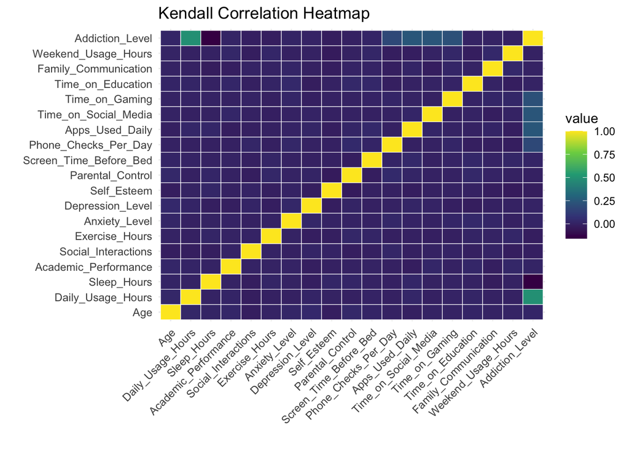

```r
#convert correlation matrix to long format
corr_melt <- melt(corr)

#heatmap
ggplot(corr_melt, aes(Var1, Var2, fill = value)) +
  geom_tile(color = "white") +
  scale_fill_viridis_c() +
  theme_minimal() +
  theme(axis.text.x = element_text(angle = 45, hjust = 1)) +
  labs(
    title = "Kendall Correlation Heatmap",
    x = "",
    y = ""
  )
```

- < 0.2 – no linear correlation
- 0.2 – 0.4 – low linear correlation
- 0.4 -0.7 – mid linear correlation
- 0.7 – 0.9 – strong linear correlation
- > 0.9 – very strong linear correlation

Correlation analysis shows that addiction level is most strongly associated with usage-intensity features, especially Daily_Usage_Hours, as well as Apps_Used_Daily, Time_on_Social_Media, Phone_Checks_Per_Day and Time_on_Gaming. A negative correlation with Sleep_Hours suggests that higher addiction levels are linked to reduced sleep, while most other variables show only weak relationships.

### Dependent Variable Analysis

```r
# summary statistics for target variable
cat("Addiction_Level Statistics:\n")
```

```
## Addiction_Level Statistics:
```

```r
cat(" Mean:", mean(df_train$Addiction_Level, na.rm = TRUE), "\n")
```

```
##  Mean: 8.887713
```

```r
cat(" Median:", median(df_train$Addiction_Level, na.rm = TRUE), "\n")
```

```
##  Median: 10
```

```r
cat(" Std Dev:", sd(df_train$Addiction_Level, na.rm = TRUE), "\n")
```

```
##  Std Dev: 1.623975
```

```r
cat(" Min:", min(df_train$Addiction_Level, na.rm = TRUE), "\n")
```

```
##  Min: 1
```

```r
cat(" Max:", max(df_train$Addiction_Level, na.rm = TRUE), "\n")
```

```
##  Max: 10
```

```r
cat(" Skewness:", skewness(df_train$Addiction_Level, na.rm = TRUE), "\n")
```

```
##  Skewness: -1.589696
```

```r
cat(" Kurtosis:", kurtosis(df_train$Addiction_Level, na.rm = TRUE), "\n")
```

```
##  Kurtosis: 2.10591
```

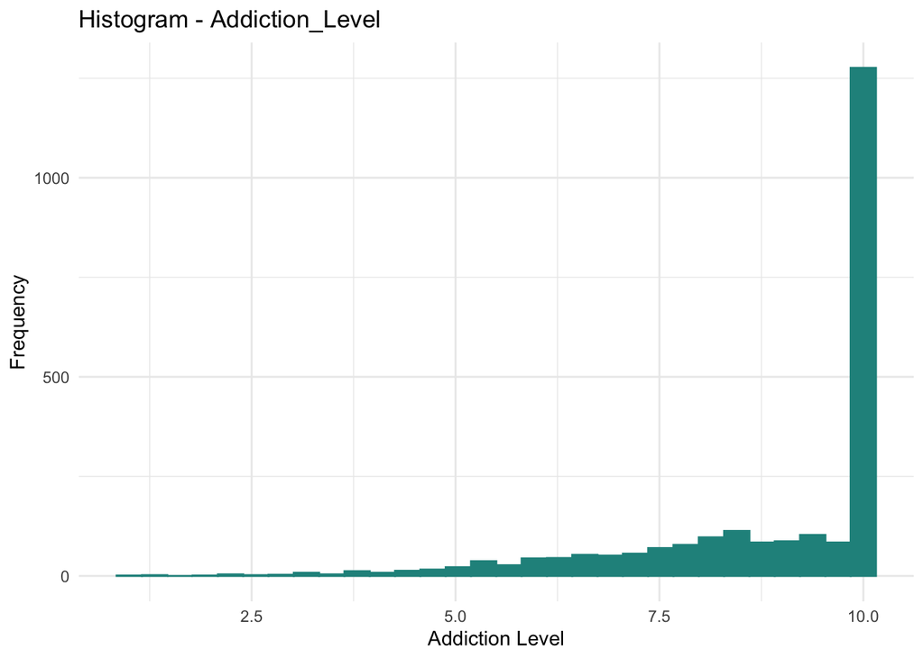

```r
# histogram of target variable
ggplot(df_train, aes(x = Addiction_Level)) +
  geom_histogram(bins = 30, fill = "#21918c", color = "#21918c") +
  labs(
    title = "Histogram - Addiction_Level",
    x = "Addiction Level",
    y = "Frequency"
  ) +
  theme_minimal()
```

```r
# skewness of target variable
skewness(df_train$Addiction_Level, na.rm = TRUE)
```

```
## [1] -1.589696
```

Let’s try log and square root transformations to improve normality

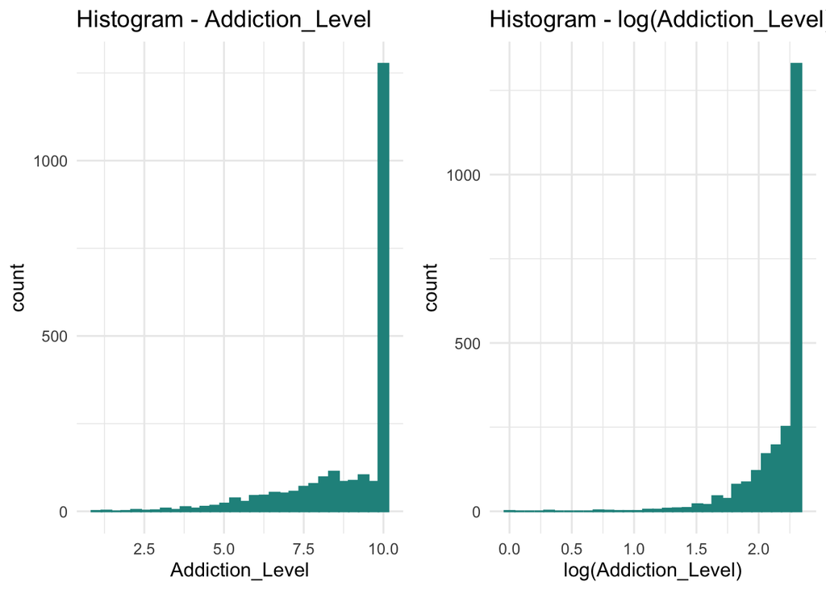

```r
# Histogram - original data
p1 <- ggplot(df_train, aes(x = Addiction_Level)) +
  geom_histogram(bins = 30, fill = "#21918c", color = "#21918c") +
  labs(title = "Histogram - Addiction_Level") +
  theme_minimal(base_size = 12)

# Histogram - log transformed
p2 <- ggplot(df_train, aes(x = log(Addiction_Level))) +
  geom_histogram(bins = 30, fill = "#21918c", color = "#21918c") +
  labs(title = "Histogram - log(Addiction_Level)") +
  theme_minimal(base_size = 12)

# Arrange plots side by side
grid.arrange(p1, p2, ncol = 2)
```

Log scaling doesn’t improve the distribution of target variable - let’s try square root.

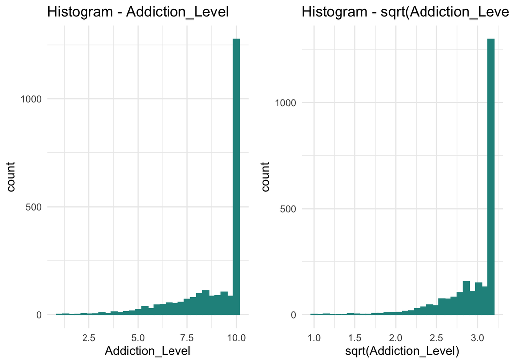

```r
# Histogram - original data
p1 <- ggplot(df_train, aes(x = Addiction_Level)) +
  geom_histogram(bins = 30, fill = "#21918c", color = "#21918c") +
  labs(title = "Histogram - Addiction_Level") +
  theme_minimal(base_size = 12)

# Histogram - sqrt transformed data
p2 <- ggplot(df_train, aes(x = sqrt(Addiction_Level))) +
  geom_histogram(bins = 30, fill = "#21918c", color = "#21918c") +
  labs(title = "Histogram - sqrt(Addiction_Level)") +
  theme_minimal(base_size = 12)

# Arrange plots side by side
grid.arrange(p1, p2, ncol = 2)
```

```r
# Original data
skew_original <- skewness(df_train$Addiction_Level, na.rm = TRUE)
kurt_original <- kurtosis(df_train$Addiction_Level, na.rm = TRUE)

# Square root transformation
skew_sqrt <- skewness(sqrt(df_train$Addiction_Level), na.rm = TRUE)
kurt_sqrt <- kurtosis(sqrt(df_train$Addiction_Level), na.rm = TRUE)

# Log transformation
skew_log <- skewness(log(df_train$Addiction_Level), na.rm = TRUE)
kurt_log <- kurtosis(log(df_train$Addiction_Level), na.rm = TRUE)

# Print results
cat("Original:")
```

```
## Original:
```

```r
cat(" Skewness:", skew_original)
```

```
##  Skewness: -1.589696
```

```r
cat(" Kurtosis:", kurt_original)
```

```
##  Kurtosis: 2.10591
```

```r
cat("Sqrt transformed:")
```

```
## Sqrt transformed:
```

```r
cat(" Skewness:", skew_sqrt)
```

```
##  Skewness: -1.985016
```

```r
cat(" Kurtosis:", kurt_sqrt)
```

```
##  Kurtosis: 4.601342
```

```r
cat("Log transformed:")
```

```
## Log transformed:
```

```r
cat(" Skewness:", skew_log)
```

```
##  Skewness: -2.70758
```

```r
cat(" Kurtosis:", kurt_log)
```

```
##  Kurtosis: 11.03116
```

The target variable Addiction_Level will be modeled in its original scale. Applied transformations such as square root and logarithm increased skewness and kurtosis and even less normal distribution. Since most machine learning models do not require the target variable to follow a normal distribution, keeping the original form is the most appropriate choice.

### Statistical Analysis

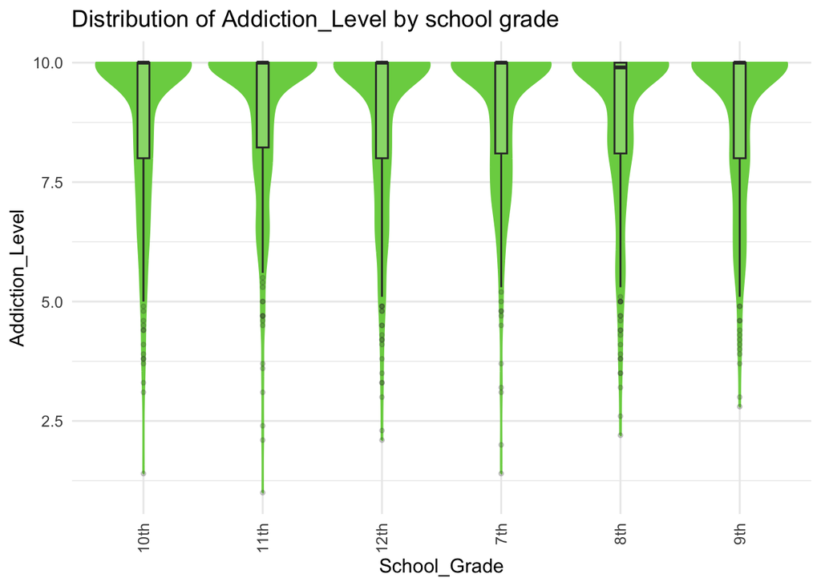

```r
# Violin plot: distribution by school grade
ggplot(df_train, aes(x = School_Grade, y = Addiction_Level)) +
  geom_violin(fill = "#7ad151", color = "#7ad151") +
  geom_boxplot(width = 0.1, outlier.size = 1, alpha = 0.2) +
  labs(title = "Distribution of Addiction_Level by school grade") +
  theme_minimal(base_size = 12) +
  theme(axis.text.x = element_text(angle = 90, vjust = 0.5, hjust = 1))
```

```r
# Perform Kruskal-Wallis test
kruskal_result <- kruskal.test(Addiction_Level ~ School_Grade, data = df_train)

# Print p-value
cat(sprintf("Kruskal-Wallis p-value = %.5f\n", kruskal_result$p.value))
```

```
## Kruskal-Wallis p-value = 0.88581
```

To statistically verify the visual differences observed in the violin plot, we applied Kruskal–Wallis. This non-parametric test was chosen due to the non-normal distribution of the target variable and the presence of multiple groups. The results indicate that there is no significant difference between addiction level across school grades.

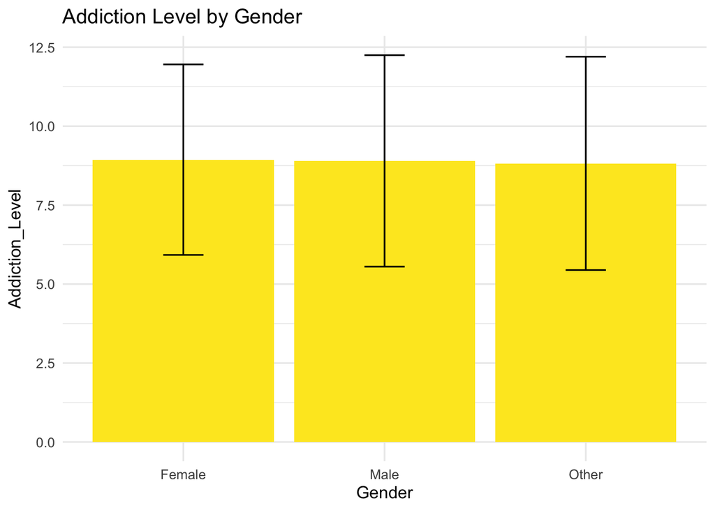

```r
# Barplot: mean Addiction_Level by Gender with SD error bars
ggplot(df_train, aes(x = Gender, y = Addiction_Level)) +
  stat_summary(fun = mean, geom = "bar", fill = "#fde725") +
  stat_summary(fun.data = mean_sdl, geom = "errorbar", width = 0.2) +
  labs(
    title = "Addiction Level by Gender",
    x = "Gender",
    y = "Addiction_Level"
  ) +
  theme_minimal(base_size = 12)
```

Addiction level seems to be consistent across all genders - there are no significant differences based on the plot output.

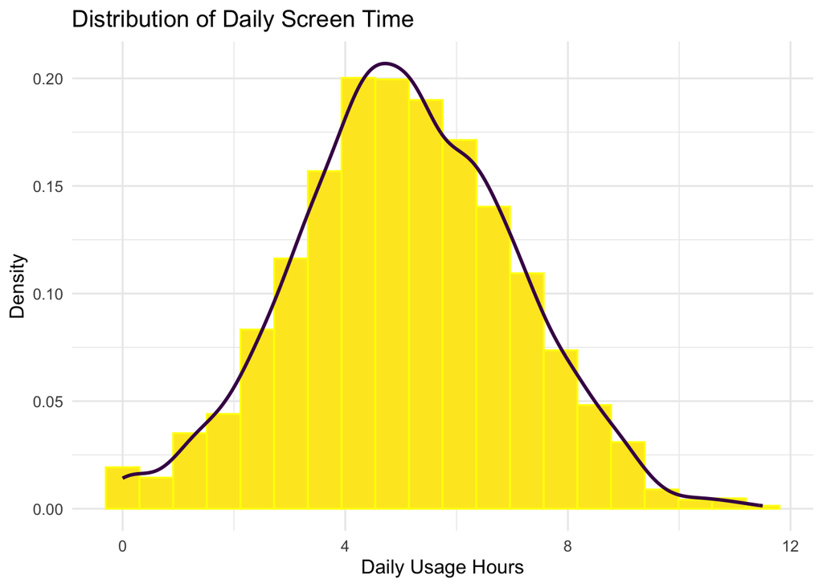

```r
# Histogram with density curve (KDE equivalent)
ggplot(df_train, aes(x = Daily_Usage_Hours)) +
  geom_histogram(aes(y = ..density..), bins = 20, fill = "#fde725", color = "yellow") +
  geom_density(color = "#440154", linewidth = 1) +
  labs(
    title = "Distribution of Daily Screen Time",
    x = "Daily Usage Hours",
    y = "Density"
  ) +
  theme_minimal(base_size = 12)
```

The plot shows that most people spend around 4 to 6 hours per day using screens. The highest frequency is in this range, while very low and very high screen time values occur less often. Overall, daily screen time is concentrated around moderate usage levels, with only a few users spending more than 8 hours per day.

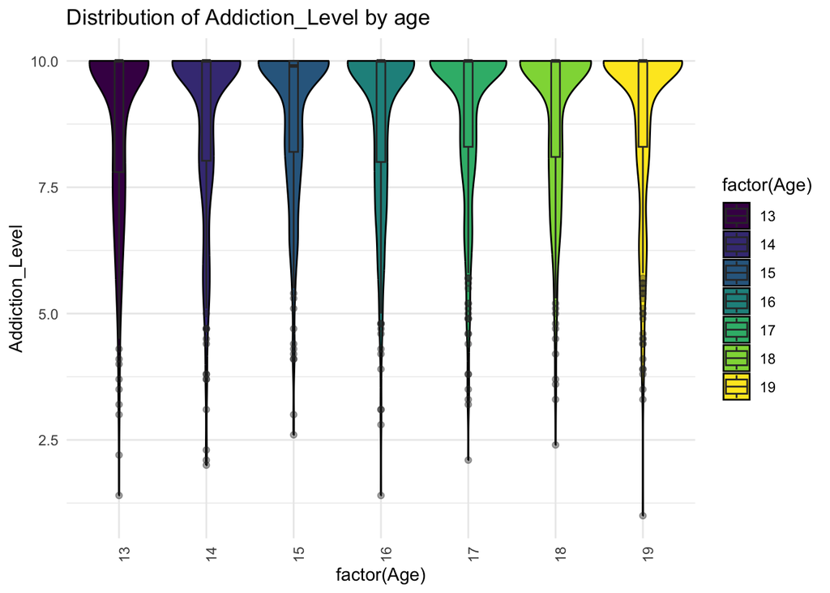

```r
# Violin plot of Addiction_Level by Age

ggplot(df_train, aes(x = factor(Age), y = Addiction_Level, fill = factor(Age))) +
  geom_violin(color = "black") +
  geom_boxplot(width = 0.1, alpha = 0.4) +
  scale_fill_viridis_d() +
  labs(title = "Distribution of Addiction_Level by age") +
  theme_minimal() +
  theme(axis.text.x = element_text(angle = 90))
```

Addiction level seems to be consistent across all age groups - there are no significant differences based on the plot output.

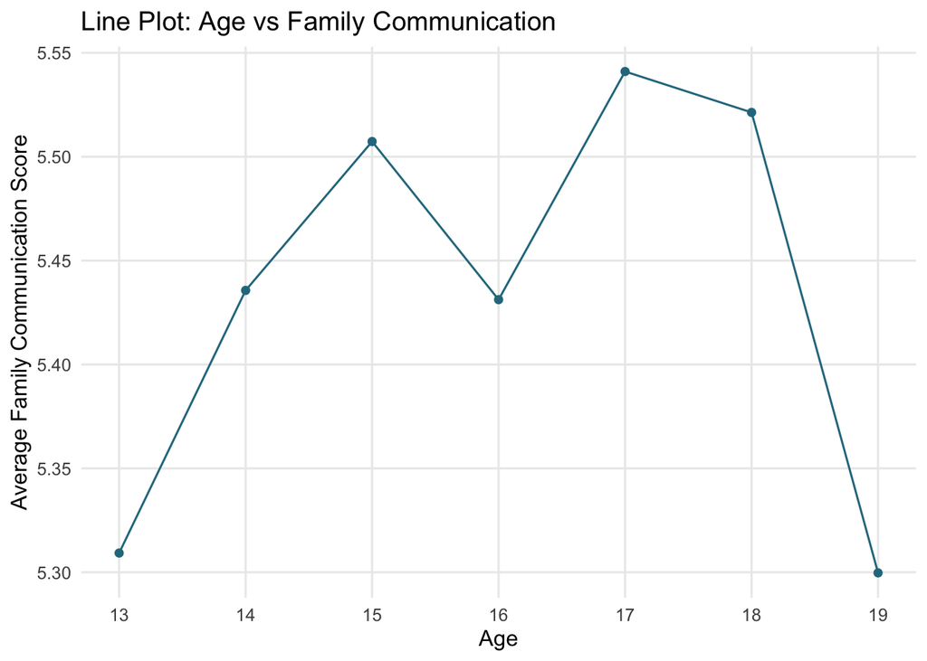

```r
# Group by Age and compute mean Family_Communication
grouped_df <- df_train %>%
  group_by(Age) %>%
  summarise(Family_Communication = mean(Family_Communication, na.rm = TRUE))

# Line plot
ggplot(grouped_df, aes(x = Age, y = Family_Communication)) +
  geom_line(color = "#2a788e") +
  geom_point(color = "#2a788e") +
  scale_x_continuous(breaks = seq(min(grouped_df$Age), max(grouped_df$Age), by = 1)) +
  labs(
    title = "Line Plot: Age vs Family Communication",
    x = "Age",
    y = "Average Family Communication Score"
  ) +
  theme_minimal(base_size = 12) +
  theme(panel.grid.minor = element_blank())
```

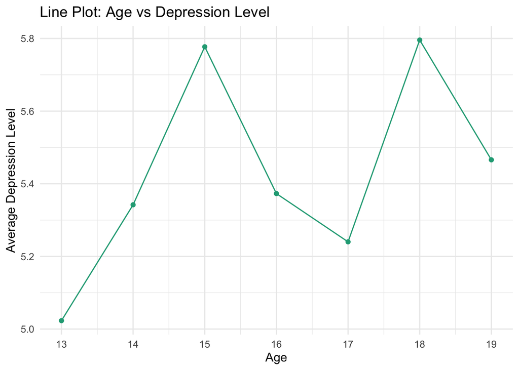

```r
# Group by Age and compute mean Depression_Level
grouped_df <- df_train %>%
  group_by(Age) %>%
  summarise(Depression_Level = mean(Depression_Level, na.rm = TRUE))

# Line plot with x-axis ticks every 1 unit
ggplot(grouped_df, aes(x = Age, y = Depression_Level)) +
  geom_line(color = "#22a884") +
  geom_point(color = "#22a884") +
  scale_x_continuous(breaks = seq(min(grouped_df$Age), max(grouped_df$Age), by = 1)) +
  labs(
    title = "Line Plot: Age vs Depression Level",
    x = "Age",
    y = "Average Depression Level"
  ) +
  theme_minimal(base_size = 12)
```

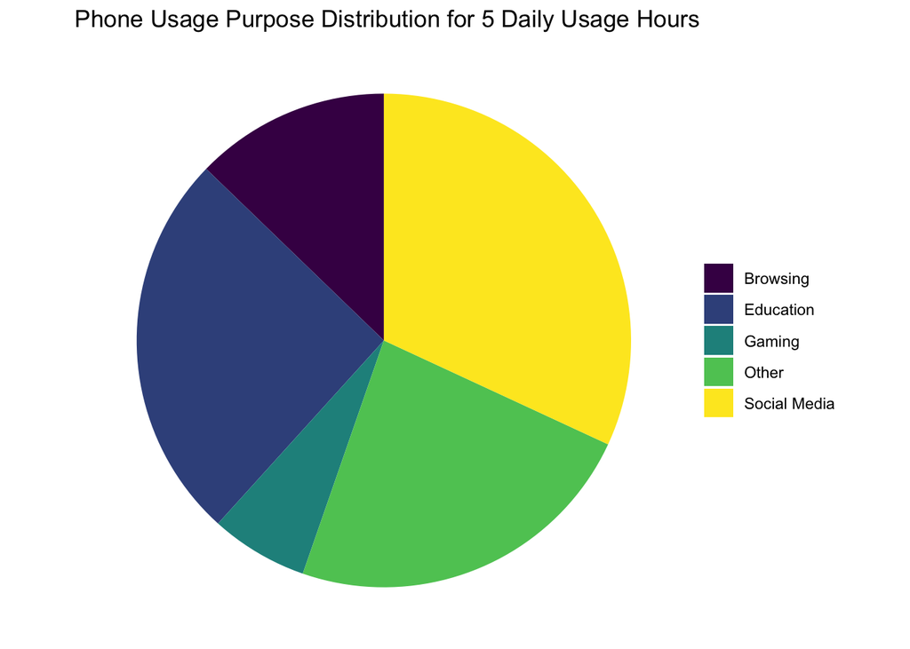

```r
# Filter dataset for specific usage hours
usage_hour <- 5
filtered_df <- df_train %>%
  filter(Daily_Usage_Hours == usage_hour)

# Count categories
purpose_counts <- filtered_df %>%
  count(Phone_Usage_Purpose)

# Pie chart
ggplot(purpose_counts, aes(x = "", y = n, fill = Phone_Usage_Purpose)) +
  geom_bar(stat = "identity", width = 1) +
  coord_polar(theta = "y") +
  scale_fill_viridis_d()+
  labs(
    title = paste("Phone Usage Purpose Distribution for", usage_hour, "Daily Usage Hours"),
    x = "",
    y = ""
  ) +
  theme_void() +
  theme(legend.title = element_blank())
```

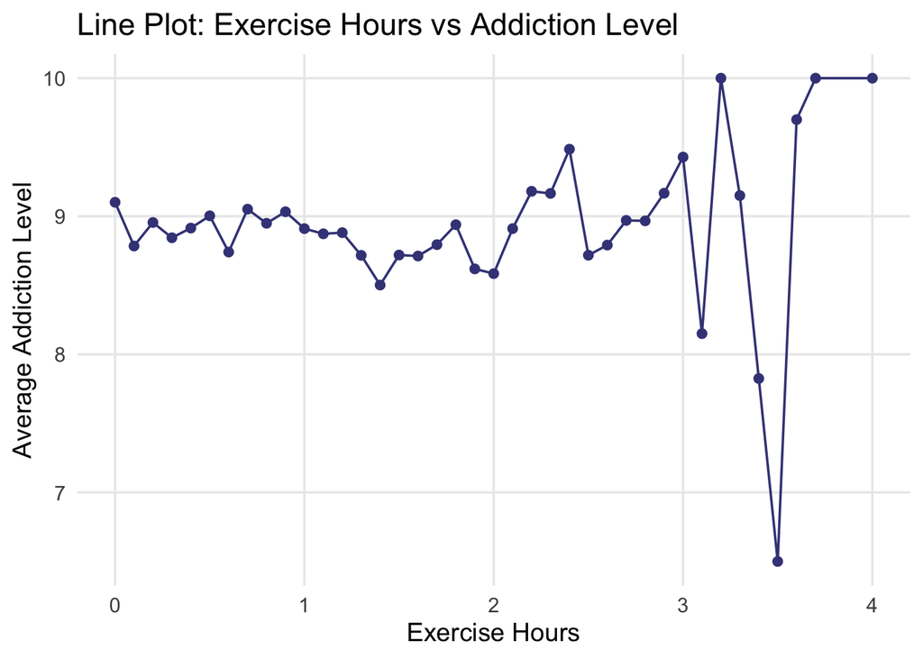

```r
# Group by Exercise_Hours and compute mean Addiction_Level
grouped_df <- df_train %>%
  group_by(Exercise_Hours) %>%
  summarise(Addiction_Level = mean(Addiction_Level, na.rm = TRUE))

# Line plot
ggplot(grouped_df, aes(x = Exercise_Hours, y = Addiction_Level)) +
  geom_line(color = "#414487") +
  geom_point(color = "#414487") +
  labs(
    title = "Line Plot: Exercise Hours vs Addiction Level",
    x = "Exercise Hours",
    y = "Average Addiction Level"
  ) +
  theme_minimal(base_size = 14) +
  theme(panel.grid.minor = element_blank())
```

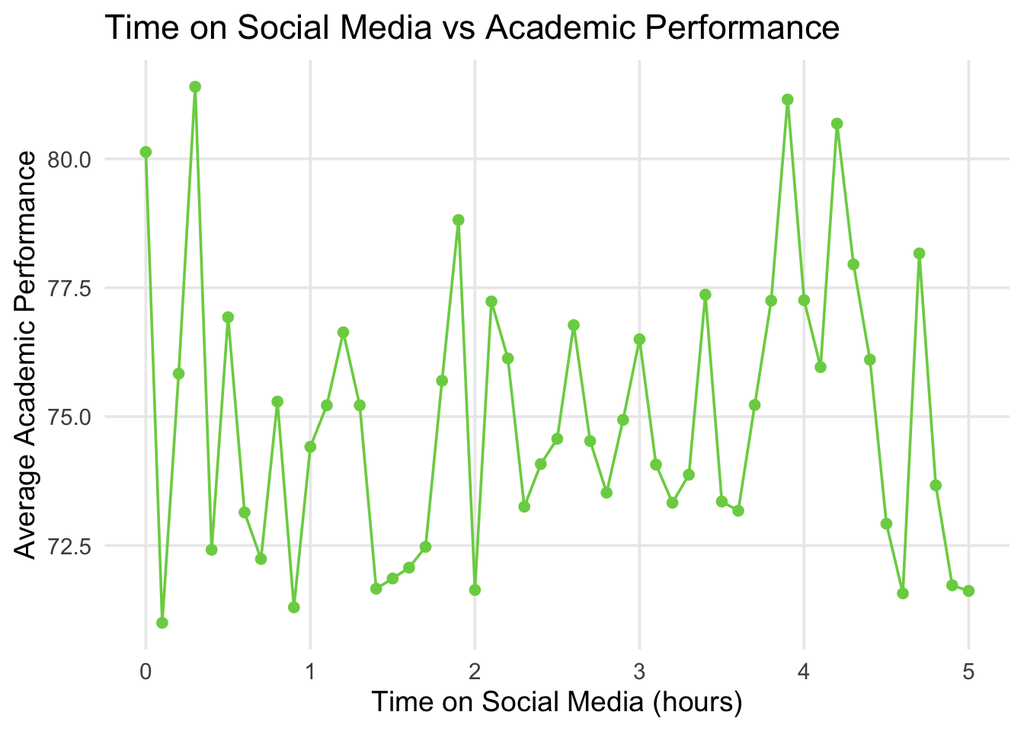

```r
# Group by Time_on_Social_Media and compute mean Academic_Performance
grouped_df <- df_train %>%
  group_by(Time_on_Social_Media) %>%
  summarise(Academic_Performance = mean(Academic_Performance, na.rm = TRUE))

# Line plot
ggplot(grouped_df, aes(x = Time_on_Social_Media, y = Academic_Performance)) +
  geom_line(color = "#7ad151") +
  geom_point(color = "#7ad151") +
  labs(
    title = "Time on Social Media vs Academic Performance",
    x = "Time on Social Media (hours)",
    y = "Average Academic Performance"
  ) +
  theme_minimal(base_size = 14) +
  theme(panel.grid.minor = element_blank())
```

This graph suggests that time on social media doesn’t have a clear or consistent impact on academic performance. The relationship seems to be more unpredictable, with academic performance fluctuating regardless of social media use.

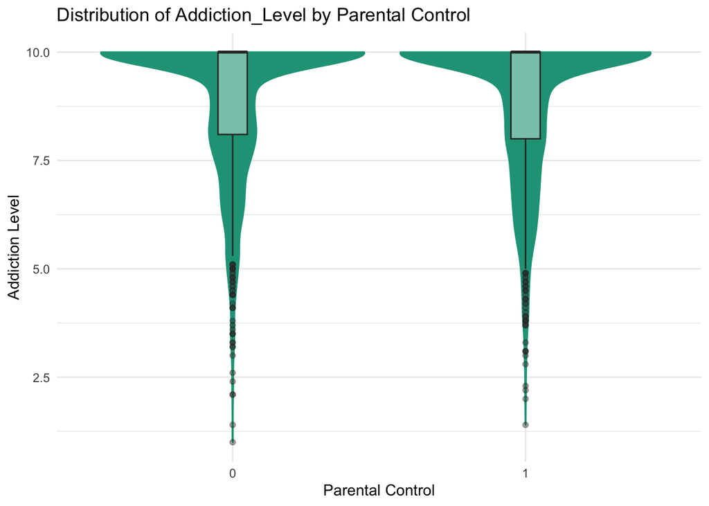

```r
ggplot(df_train, aes(x = factor(Parental_Control), y = Addiction_Level)) +
  geom_violin(fill = "#1fa187", color = "#1fa187") +
  geom_boxplot(width = 0.1, alpha = 0.4) +
  labs(
    title = "Distribution of Addiction_Level by Parental Control",
    x = "Parental Control",
    y = "Addiction Level"
  ) +
  theme_minimal()
```

Addiction level seems to be consistent across both groups - there are no significant differences based on the plot output.

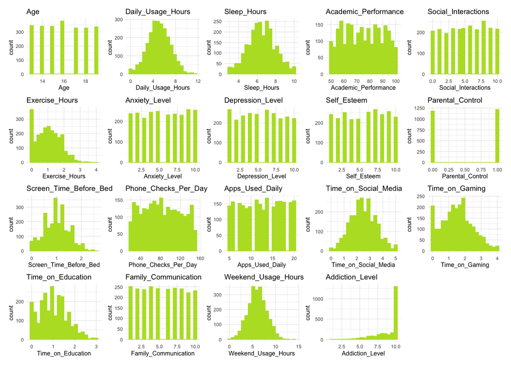

```r
# Numeric columns selection
num_df <- df_train %>% select(where(is.numeric))

# Plots
plot_list <- lapply(names(num_df), function(col) {
  ggplot(num_df, aes(x = .data[[col]])) +
    geom_histogram(bins = 20, fill = "#b5de2b", color = "#b5de2b") +
    labs(title = col) +
    theme_minimal(base_size = 6)
})

# Combine plots
wrap_plots(plot_list)
```

# Section 4: Feature Engineering

We’ll create derived features to capture behavioral patterns, reduce dimensionality, and improve model performance.

### One-hot-encoding on Gender, School_Grade & Phone_Usage_Purpose

```r
df_train_encoded <- model.matrix(~ Gender + School_Grade + Phone_Usage_Purpose, data = df_train) |> as.data.frame()

df_train_encoded <- df_train_encoded[, !names(df_train_encoded) %in% "(Intercept)"]

# Keeping only encoded
df_train <- cbind(df_train[, !names(df_train) %in% c("Gender", "School_Grade", "Phone_Usage_Purpose")],
            df_train_encoded)

str(df_train)
```

```
## 'data.frame':    2401 obs. of  30 variables:
##  $ Age                            : int  17 13 18 13 16 13 13 18 14 19 ...
##  $ Daily_Usage_Hours              : num  5.5 5.8 3.1 3.9 6.3 5.1 3 4.9 1.6 7.4 ...
##  $ Sleep_Hours                    : num  6.5 5.5 3.9 6.3 6.7 6.1 9.1 7 5.9 5.8 ...
##  $ Academic_Performance           : int  70 93 78 89 89 70 79 74 70 70 ...
##  $ Social_Interactions            : int  5 8 8 3 3 2 0 5 10 4 ...
##  $ Exercise_Hours                 : num  0 0.8 1.6 0.7 0.9 2.2 1.8 0.6 1.5 0.6 ...
##  $ Anxiety_Level                  : int  3 2 9 7 6 5 1 4 10 4 ...
##  $ Depression_Level               : int  7 3 10 1 7 6 7 3 8 9 ...
##  $ Self_Esteem                    : int  3 10 3 3 9 8 6 2 8 3 ...
##  $ Parental_Control               : int  0 0 0 0 0 0 0 0 0 0 ...
##  $ Screen_Time_Before_Bed         : num  0.9 0.5 1.4 1.1 0.8 1 0.9 0.6 0.9 1.1 ...
##  $ Phone_Checks_Per_Day           : int  96 137 128 135 129 34 70 84 147 59 ...
##  $ Apps_Used_Daily                : int  9 8 7 8 9 7 13 20 18 19 ...
##  $ Time_on_Social_Media           : num  1.1 0.3 3.1 3.8 1.8 2.3 2.7 3.1 1.9 4.3 ...
```

[output cut: 16 more lines]

### Additional features

We created additional features to better capture behavioral patterns related to smartphone usage, including usage intensity, night-time activity, and lifestyle balance.

- **Total_Phone_Time** – total daily time spent on the phone, calculated as the sum of social media, gaming, and educational usage. It represents overall smartphone exposure.
- **Checks_per_Hour** – the number of phone checks normalized by daily usage hours, capturing compulsive checking behavior rather than long continuous sessions.
- **Night_Usage_Ratio** – the proportion of total phone usage that occurs before bedtime, reflecting potentially unhealthy night-time usage patterns.
- **Digital_Life_Balance** – a ratio combining sleep and physical activity relative to phone usage, indicating the balance between offline lifestyle and digital behavior.
- **Entertainment_to_Education_Ratio** – the relationship between entertainment-related phone use (social media and gaming) and educational use, distinguishing productive from leisure-oriented behavior.
- **Exercise_Level** – a categorical variable derived from weekly exercise hours, grouping physical activity into very low, low, moderate, and high levels to improve interpretability.

```r
df_train$Total_Phone_Time <- df_train$Time_on_Social_Media + df_train$Time_on_Gaming + df_train$Time_on_Education
df_train$Checks_per_Hour <- df_train$Phone_Checks_Per_Day / (df_train$Daily_Usage_Hours + 1e-12)
df_train$Night_Usage_Ratio <- df_train$Screen_Time_Before_Bed / (df_train$Daily_Usage_Hours + 1e-12)
df_train$Digital_Life_Balance <- (df_train$Exercise_Hours + df_train$Sleep_Hours) / (df_train$Daily_Usage_Hours + 1e-12)

df_train$Entertainment_to_Education_Ratio <-(df_train$Time_on_Social_Media + df_train$Time_on_Gaming) / (df_train$Time_on_Education + 1e-12)

df_train$Exercise_Level <- cut(df_train$Exercise_Hours, breaks = c(-1, 1, 3, 6, 20), labels = c("Very Low", "Low", "Moderate", "High"))
exercise_dummies <- model.matrix(~ Exercise_Level, data = df_train) |>as.data.frame()
exercise_dummies <- exercise_dummies[, !names(exercise_dummies) %in% "(Intercept)"]
df_train <- cbind(df_train[, !names(df_train) %in% "Exercise_Level"], exercise_dummies)
```

At this step for python version from Machine Learning 1 course we’ve taken code for downcasting our dataframe. The function downcast_dataframe() is used to reduce the memory usage of a DataFrame by converting each column to the smallest possible data type that can still hold all its values. Downcasting can reduce memory usage by 50–90%.

In **R version** we decided to omit this function - R primarily operates with just two numeric types (integer and double), and more granular downcasting is not easily supported and would require additional packages. Taking into consideration our small dataset and very little potential memory savings the change would be neglible.

```r
# Apply same transformations to test set

# Drop location
df_test <- df_test[, !names(df_test) %in% "Location"]

# One-hot
test_dummies <- model.matrix(~ Gender + School_Grade + Phone_Usage_Purpose, data = df_test) |> as.data.frame()
test_dummies <- test_dummies[, !names(test_dummies) %in% "(Intercept)"]
df_test <- cbind(df_test[, !names(df_test) %in% c("Gender", "School_Grade", "Phone_Usage_Purpose")], test_dummies)

# New features
df_test$Total_Phone_Time <- df_test$Time_on_Social_Media + df_test$Time_on_Gaming + df_test$Time_on_Education
df_test$Checks_per_Hour <- df_test$Phone_Checks_Per_Day / (df_test$Daily_Usage_Hours + 1e-12)
df_test$Night_Usage_Ratio <- df_test$Screen_Time_Before_Bed / (df_test$Daily_Usage_Hours + 1e-12)
df_test$Digital_Life_Balance <- (df_test$Exercise_Hours + df_test$Sleep_Hours) / (df_test$Daily_Usage_Hours + 1e-12)

df_test$Entertainment_to_Education_Ratio <- (df_test$Time_on_Social_Media + df_test$Time_on_Gaming) /     (df_test$Time_on_Education + 1e-3)

df_test$Exercise_Level <- cut( df_test$Exercise_Hours, breaks = c(-1, 1, 3, 6, 20), labels = c("Very Low", "Low", "Moderate", "High"))
exercise_dummies_test <- model.matrix(~ Exercise_Level, data = df_test) |> as.data.frame()
exercise_dummies_test <- exercise_dummies_test[, !names(exercise_dummies_test) %in% "(Intercept)"]
df_test <- cbind(df_test[, !names(df_test) %in% "Exercise_Level"], exercise_dummies_test)
```

```r
setdiff(names(df_train), names(df_test))
```

```
## character(0)
```

```r
setdiff(names(df_test), names(df_train))
```

```
## character(0)
```

# Section 5: Model Training with Decision Tree Regressor

Reason for choosing this model for our problem:

Baseline model - Trees are interpretable and capture non-linear relationships without requiring feature scaling Feature importance - Directly reveals which variables matter most for predicting addiction No assumptions - Unlike linear models, doesn’t assume linear relationships between predictors and addiction level

## Step 1: Prepare training and test data

```r
# Separate predictors and target variable

x_train <- df_train %>%
  select(-Addiction_Level)

y_train <- df_train$Addiction_Level

x_test <- df_test %>%
  select(-Addiction_Level)

y_test <- df_test$Addiction_Level
```

```r
set.seed(42)

cv_control <- trainControl(
  method = "cv",
  number = 5
)
```

```r
# create copies for modeling
df_train_model <- df_train
df_test_model <- df_test

# remove target before NZV check
predictors_train <- df_train_model %>%
  select(-Addiction_Level)

predictors_test <- df_test_model %>%
  select(-Addiction_Level)

# detect near-zero variance predictors
nzv <- nearZeroVar(predictors_train)

# remove problematic predictors
if(length(nzv) > 0){
  predictors_train <- predictors_train[, -nzv]
  predictors_test <- predictors_test[, -nzv]
}

# add target back
df_train_model <- cbind(
  Addiction_Level = df_train_model$Addiction_Level,
  predictors_train
)

df_test_model <- cbind(
  Addiction_Level = df_test_model$Addiction_Level,
  predictors_test
)

cat("Removed predictors:", length(nzv), "\n")
```

```
## Removed predictors: 2
```

```r
# sanity check
"Addiction_Level" %in% names(df_train_model)
```

```
## [1] TRUE
```

[figure not shown]

```r
set.seed(42)

dt_model <- rpart(
  Addiction_Level ~ .,
  data = df_train_model,
  method = "anova",
  control = rpart.control(
    minsplit = 2,
    minbucket = 5,
    cp = 0,
    maxdepth = 30
  )
)



rpart.plot(dt_model,
           type = 2,
           extra = 101,
           fallen.leaves = TRUE,
           box.palette = viridis(100, option = "D")
           )
```

```r
# Predictions
dt_predictions <- predict(
  dt_model,
  newdata = df_test_model
)

# Metrics
dt_results <- postResample(
  pred = dt_predictions,
  obs = df_test_model$Addiction_Level
)

print(dt_results)
```

```
##      RMSE  Rsquared       MAE
## 0.8962308 0.6957902 0.5394673
```

The R implementation achieved performance metrics comparable to the original Python model. Although slight differences were observed (likely due to implementation differences between DecisionTreeRegressor in scikit-learn and rpart in R), the overall predictive performance remained similar, confirming successful model reproduction. The Decision Tree achieved strong predictive performance with an R² of 0.696, meaning it explains 69.6% of the variance in addiction levels. On average, predictions deviate by 0.539 points (MAE) from actual addiction scores.

# Section 6: Model Training with Random Forest Regressor

Random Forest builds multiple decision trees and averages predictions for better generalization.

Reason for choosing this model for our problem: - Reduces overfitting - Multiple trees with bootstrapped samples and feature randomness create robust predictions - Feature importance ranking - Aggregates importance across all trees, giving reliable feature rankings - Robust to outliers - our target variable distribution has skewness and outliers and Random Forest is less sensitive for them

```r
set.seed(42)

names(df_train_model)[
  names(df_train_model) == "Phone_Usage_PurposeSocial Media"
] <- "Phone_Usage_PurposeSocialMedia"

names(df_test_model)[
  names(df_test_model) == "Phone_Usage_PurposeSocial Media"] <- "Phone_Usage_PurposeSocialMedia"
```

```r
# Train Random Forest Regressor
rf_model <- randomForest(
  Addiction_Level ~ .,
  data = df_train_model,
  ntree = 400,         # n_estimators
  mtry = floor(ncol(df_train_model[-1]) * 0.5),  # max_features = 0.5
  nodesize = 1,        # min_samples_leaf = 1
  importance = TRUE
)

print(rf_model)
```

```
##
## Call:
##  randomForest(formula = Addiction_Level ~ ., data = df_train_model,      ntree = 400, mtry = floor(ncol(df_train_model[-1]) * 0.5),      nodesize = 1, importance = TRUE)
##                Type of random forest: regression
##                      Number of trees: 400
## No. of variables tried at each split: 17
##
##           Mean of squared residuals: 0.2774051
##                     % Var explained: 89.48
```

```r
# Predictions
rf_predictions <- predict(
  rf_model,
  newdata = df_test_model
)

# Metrics
rf_results <- postResample(
  pred = rf_predictions,
  obs = df_test_model$Addiction_Level
)

print(rf_results)
```

```
##      RMSE  Rsquared       MAE
## 0.5270994 0.9016737 0.3713318
```

This Random Forest model was successfully reproduced in R, achieving nearly identical predictive performance to the original Python implementation. Minor metric differences are expected due to implementation differences between scikit-learn and randomForest in R.

The Random Forest model significantly outperforms the Decision Tree, achieving an R² of 0.9016 (explaining 90.16% of variance in addiction levels) with a lower MAE of 0.371, demonstrating that ensemble methods with multiple trees and bootstrap sampling effectively reduce overfitting and capture complex behavioral patterns in smartphone addiction prediction.

# Section 7: Model Training with AdaBoost Regressor

AdaBoost builds an ensemble of weak learners, focusing on instances that previous models found difficult.

Reason for choosing this model for our problem: - Sequential learning - Focuses on instances the previous model misclassified, reducing bias and variance - Handles difficult cases - Emphasizes harder-to-predict addiction levels, improving overall performance - Adaptive weighting - Learns which samples are most informative for addiction prediction task - Prevents underfitting - Particularly useful when simpler models underfit complex behavioral patterns

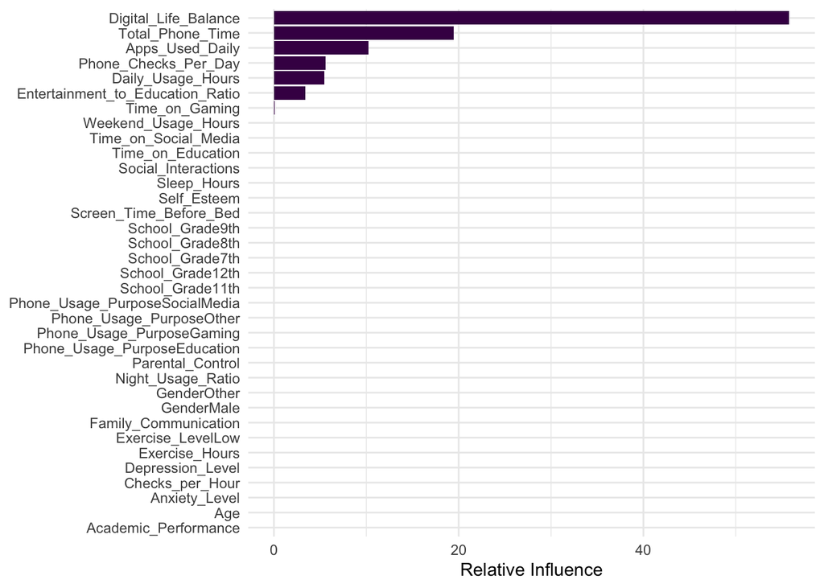

```r
set.seed(42)

# Train boosting model

ada_model <- gbm(
  formula = Addiction_Level ~ .,
  data = df_train_model,
  distribution = "gaussian",
  n.trees = 100,          # n_estimators
  interaction.depth = 2, # max_depth = 2
  shrinkage = 0.05,      # learning_rate
  bag.fraction = 1.0,
  cv.folds = 5,
  verbose = FALSE
)

# Debbuged with ChatGPT to match viridis

imp <- summary(ada_model, plotit = FALSE)

ggplot(imp,
       aes(
         x = reorder(var, rel.inf),
         y = rel.inf)) +
  geom_col(fill = viridis(1)) +
  coord_flip() +
  labs(
    x = NULL,
    y = "Relative Influence"
    ) + theme_minimal()
```

```r
# Predictions
ada_predictions <- predict(
  ada_model,
  newdata = df_test_model,
  n.trees = 100
)

# Metrics
ada_results <- postResample(
  pred = ada_predictions,
  obs = df_test_model$Addiction_Level
)

print(ada_results)
```

```
##      RMSE  Rsquared       MAE
## 0.7389755 0.8036426 0.5405943
```

Due to implementation limitations of AdaBoost regression in R, a gradient boosting approach (gbm) was used as the closest available alternative. The reproduced model achieved improved predictive performance compared to the original Python implementation.

The boosting model in R achieved better predictive performance than the original Python implementation (RMSE = 0.739 vs. 1.003; R² = 0.804 vs. 0.564). This difference is likely explained by implementation differences, as the Python model relied on AdaBoostRegressor, whereas the R version used gradient boosting (gbm), which is generally more flexible and capable of capturing complex relationships in the data.

# Section 8: Predictions on added set of new data

Lastly in our project we wanted to check whether predictions on the generated data will be as good as on the original dataset. In our R pipline Random Forest was the best predictive performance, obtaining the lowest RMSE (0.527) and MAE (0.371). To check that we created the python scripts, which generates 500 new lines of observations each time.

This part was partially coded with the ChatGPT due to ensure reprudicibility on different enviroment not only on those used byt the authors.

```r
# run script - requirements with fallbacks
python_cmd <- Sys.which("python3")
conda_python <- "/opt/anaconda3/bin/python"

if (file.exists(conda_python)) {python_cmd <- conda_python}
if (python_cmd == "") {stop("Python not found.")}

script_path <- "../scripts/generate_new_records.py"

if (!file.exists(script_path)) {stop("Script not found. Check your working directory with getwd().")}

old_wd <- getwd()
on.exit(setwd(old_wd))

setwd("..")

system2(python_cmd, "scripts/generate_new_records.py")
```

```r
new_records <- read.csv("../scripts/new_records.csv")

# Cleaning
new_records_predictors <- new_records[, !names(new_records) %in% "Addiction_Level"]
new_records_predictors <- new_records_predictors %>% select(-Name, -ID, -Location)

# One-hot encoding like in training/test
new_records_encoded <- model.matrix(~ Gender + School_Grade + Phone_Usage_Purpose, data = new_records_predictors) |> as.data.frame()
new_records_encoded <- new_records_encoded[ , !names(new_records_encoded) %in% "(Intercept)"]
new_records_model <- cbind(new_records_predictors[ , !names(new_records_predictors) %in% c("Gender", "School_Grade", "Phone_Usage_Purpose")], new_records_encoded)

# Same new features
new_records_model$Total_Phone_Time <- new_records_model$Time_on_Social_Media + new_records_model$Time_on_Gaming + new_records_model$Time_on_Education
new_records_model$Checks_per_Hour <- new_records_model$Phone_Checks_Per_Day / (new_records_model$Daily_Usage_Hours + 1e-12)
new_records_model$Night_Usage_Ratio <- new_records_model$Screen_Time_Before_Bed / (new_records_model$Daily_Usage_Hours + 1e-12)
new_records_model$Digital_Life_Balance <- (new_records_model$Exercise_Hours + new_records_model$Sleep_Hours) / (new_records_model$Daily_Usage_Hours + 1e-12)
new_records_model$Entertainment_to_Education_Ratio <- (new_records_model$Time_on_Social_Media + new_records_model$Time_on_Gaming) /(new_records_model$Time_on_Education + 1e-12)
new_records_model$Exercise_Level <- cut(new_records_model$Exercise_Hours, breaks = c(-1, 1, 3, 6, 20), labels = c("Very Low", "Low", "Moderate", "High"))

exercise_dummies_new <- model.matrix(~ Exercise_Level, data = new_records_model) |> as.data.frame()
exercise_dummies_new <- exercise_dummies_new[, !names(exercise_dummies_new) %in% "(Intercept)"]
new_records_model <- cbind(new_records_model[, !names(new_records_model) %in% "Exercise_Level"], exercise_dummies_new)

# Fixing names like in training process
names(new_records_model)[names(new_records_model) == "Phone_Usage_PurposeSocial Media"] <- "Phone_Usage_PurposeSocialMedia"
model_features <- setdiff(names(df_train_model), "Addiction_Level")
missing_cols <- setdiff(model_features, names(new_records_model))

for (col in missing_cols) {
  new_records_model[[col]] <- 0
}

new_records_model <- new_records_model[, model_features]

# Prediction - RF
new_records$Predicted_Addiction_Level <- predict(rf_model, newdata = new_records_model)

# Metrics on generated data
new_results <- postResample(pred = new_records$Predicted_Addiction_Level, obs = new_records$Addiction_Level)
print(new_results)
```

```
##     RMSE Rsquared      MAE
## 5.656272 0.443224 5.569240
```

```r
metrics_comparison <- rbind(Original_Test_Set = rf_results, Generated_Data = new_results)
print(metrics_comparison)
```

```
##                        RMSE  Rsquared       MAE
## Original_Test_Set 0.5270994 0.9016737 0.3713318
## Generated_Data    5.6562724 0.4432240 5.5692395
```

The genearted data consist of 500 new records. As we observed RF was great on the original datset, its performance is much worse on the synthetically generated dataset. This suggests that the generated observations are not fully in line with the relationships present in the original data. This simple script, which generates data in our experiment provided different distributions of the variables than in the original dataset. This led to reduced predictive power and shows that machine learning models generalize well only when new observations follow patterns similar to those present in the training data.